# Final Model Pipeline

Project: Hospital 30-Day Readmission Risk Prediction

This script contains the final modelling approach only. Old experiments and alternative models are intentionally excluded.

```python
import json
import joblib
import numpy as np
import pandas as pd

from pathlib import Path
from sklearn.model_selection import train_test_split
from sklearn.compose import ColumnTransformer
from sklearn.pipeline import Pipeline
from sklearn.preprocessing import OneHotEncoder
from sklearn.impute import SimpleImputer
from sklearn.linear_model import LinearRegression
from sklearn.metrics import mean_absolute_error, mean_squared_error, r2_score
```

## Load dataset

```python
DATA_PATH = "readmissions.csv"
OUTPUT_DIR = Path("outputs")
OUTPUT_DIR.mkdir(exist_ok=True)

df = pd.read_csv(DATA_PATH)

print("Dataset loaded successfully")
print(f"Shape: {df.shape}")
```

```
Dataset loaded successfully
Shape: (101766, 50)
```

## Create final target: readmitted_30_days

```python
df["readmitted_30_days"] = (df["readmitted"] == "<30").astype(int)

print("\nTarget distribution:")
print(df["readmitted_30_days"].value_counts(normalize=True))
```

```
Target distribution:
readmitted_30_days
0    0.888401
1    0.111599
Name: proportion, dtype: float64
```

## Remove unneccesary collumns

```python
columns_to_drop = [
    "readmitted",          # original target
    "encounter_id",        # administrative identifier
    "patient_nbr",         # administrative identifier
    "weight",              # too many missing values
    "payer_code",          # many missing values / not clinically central
    "medical_specialty"    # many missing values
]

df_model = df.drop(columns=columns_to_drop, errors="ignore")

X = df_model.drop(columns=["readmitted_30_days"])
y = df_model["readmitted_30_days"]

X = X.replace("?", np.nan)
```

## Data preprocessing

```python
numeric_features = X.select_dtypes(include=["int64", "float64"]).columns
categorical_features = X.select_dtypes(include=["object"]).columns

numeric_pipeline = Pipeline(steps=[
    ("imputer", SimpleImputer(strategy="median"))
])

categorical_pipeline = Pipeline(steps=[
    ("imputer", SimpleImputer(strategy="most_frequent")),
    ("encoder", OneHotEncoder(handle_unknown="ignore"))
])

preprocessor = ColumnTransformer(
    transformers=[
        ("num", numeric_pipeline, numeric_features),
        ("cat", categorical_pipeline, categorical_features)
    ]
)
```

## Train regression model

```python
X_train, X_test, y_train, y_test = train_test_split(
    X,
    y,
    test_size=0.2,
    random_state=42
)

model = Pipeline(steps=[
    ("preprocessor", preprocessor),
    ("regressor", LinearRegression())
])

model.fit(X_train, y_train)

print("\nModel trained successfully")
```

```
Model trained successfully
```

## Evaluate model

```python
y_pred = model.predict(X_test)

# Clip predictions to 0–1 for stakeholder-friendly risk interpretation
y_pred_clipped = np.clip(y_pred, 0, 1)

mae = mean_absolute_error(y_test, y_pred_clipped)
rmse = np.sqrt(mean_squared_error(y_test, y_pred_clipped))
r2 = r2_score(y_test, y_pred_clipped)

evaluation_results = {
    "model": "Linear Regression Baseline",
    "target": "readmitted_30_days",
    "MAE": round(mae, 4),
    "RMSE": round(rmse, 4),
    "R2": round(r2, 4),
    "interpretation": {
        "MAE": "Average prediction error on a 0 to 1 risk scale.",
        "RMSE": "Penalizes larger prediction errors more strongly.",
        "R2": "Explains how much variance is captured by the model."
    }
}


print("\nEvaluation Results:")
for key, value in evaluation_results.items():
    if key != "interpretation":
        print(f"{key}: {value}")


# --------------------------------------------------
# 7. Save model
# --------------------------------------------------

model_path = OUTPUT_DIR / "final_readmission_regression_model.joblib"
joblib.dump(model, model_path)

print(f"\nModel saved to: {model_path}")
```

```
Evaluation Results:
model: Linear Regression Baseline
target: readmitted_30_days
MAE: 0.1916
RMSE: 0.3125
R2: 0.0204

Model saved to: outputs/final_readmission_regression_model.joblib
```

## Model data saved

```python
model_path = OUTPUT_DIR / "final_readmission_regression_model.joblib"
joblib.dump(model, model_path)

print(f"\nModel saved to: {model_path}")


# --------------------------------------------------
# 8. Save evaluation results
# --------------------------------------------------

results_path = OUTPUT_DIR / "evaluation_results.json"

with open(results_path, "w") as f:
    json.dump(evaluation_results, f, indent=4)

predictions_path = OUTPUT_DIR / "test_predictions.csv"

predictions_df = pd.DataFrame({
    "actual": y_test.values,
    "predicted_risk_raw": y_pred,
    "predicted_risk_clipped": y_pred_clipped
})

predictions_df.to_csv(predictions_path, index=False)

print(f"Evaluation results saved to: {results_path}")
print(f"Predictions saved to: {predictions_path}")
```

```
Model saved to: outputs/final_readmission_regression_model.joblib
Evaluation results saved to: outputs/evaluation_results.json
Predictions saved to: outputs/test_predictions.csv
```

```python
predictions_df.head(20)
```

|  | actual | predicted_risk_raw | predicted_risk_clipped |
| --- | --- | --- | --- |
| 0 | 0 | 0.102961 | 0.102961 |
| 1 | 0 | 0.008037 | 0.008037 |
| 2 | 0 | 0.209484 | 0.209484 |
| 3 | 0 | 0.589219 | 0.589219 |
| 4 | 1 | 0.098385 | 0.098385 |
| 5 | 0 | 0.056352 | 0.056352 |
| 6 | 0 | 0.163134 | 0.163134 |
| 7 | 0 | 0.173563 | 0.173563 |
| 8 | 1 | 0.141512 | 0.141512 |
| 9 | 0 | 0.074685 | 0.074685 |
| 10 | 1 | 0.112024 | 0.112024 |
| 11 | 0 | 0.080725 | 0.080725 |
| 12 | 0 | 0.040696 | 0.040696 |
| 13 | 1 | 0.223667 | 0.223667 |
| 14 | 0 | 0.085003 | 0.085003 |
| 15 | 0 | 0.020674 | 0.020674 |
| 16 | 0 | 0.131359 | 0.131359 |
| 17 | 0 | 0.111328 | 0.111328 |
| 18 | 1 | 0.125749 | 0.125749 |
| 19 | 0 | 0.108163 | 0.108163 |

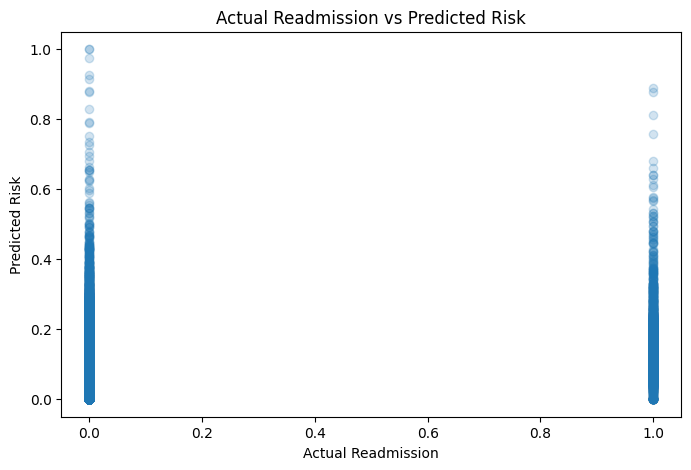

```python
plt.figure(figsize=(8,5))

plt.scatter(
    y_test,
    y_pred_clipped,
    alpha=0.2
)

plt.xlabel("Actual Readmission")
plt.ylabel("Predicted Risk")
plt.title("Actual Readmission vs Predicted Risk")

plt.show()
```

```python
predictions_df["predicted_risk_clipped"].describe()
```

```
count    20354.000000
mean         0.112614
std          0.077439
min          0.000000
25%          0.063808
50%          0.099310
75%          0.146020
max          1.000000
Name: predicted_risk_clipped, dtype: float64
```

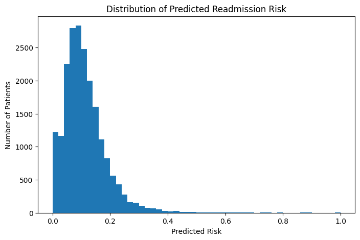

```python
import matplotlib.pyplot as plt

plt.figure(figsize=(8,5))

plt.hist(
    predictions_df["predicted_risk_clipped"],
    bins=50
)

plt.title("Distribution of Predicted Readmission Risk")
plt.xlabel("Predicted Risk")
plt.ylabel("Number of Patients")

plt.show()
```

```python
predictions_df.sort_values(
    "predicted_risk_clipped",
    ascending=False
).head(20)
```

|  | actual | predicted_risk_raw | predicted_risk_clipped |
| --- | --- | --- | --- |
| 9124 | 0 | 1.170702 | 1.000000 |
| 3697 | 0 | 1.238714 | 1.000000 |
| 14654 | 0 | 0.973624 | 0.973624 |
| 20286 | 0 | 0.925084 | 0.925084 |
| 3705 | 0 | 0.915503 | 0.915503 |
| 19128 | 1 | 0.890391 | 0.890391 |
| 875 | 0 | 0.881987 | 0.881987 |
| 5270 | 1 | 0.877022 | 0.877022 |
| 10723 | 0 | 0.876789 | 0.876789 |
| 18759 | 0 | 0.830543 | 0.830543 |
| 7491 | 1 | 0.813463 | 0.813463 |
| 1842 | 0 | 0.790684 | 0.790684 |
| 5857 | 0 | 0.789483 | 0.789483 |
| 7279 | 1 | 0.758558 | 0.758558 |
| 18378 | 0 | 0.753475 | 0.753475 |
| 1509 | 0 | 0.734734 | 0.734734 |
| 2187 | 0 | 0.727664 | 0.727664 |
| 9991 | 0 | 0.707494 | 0.707494 |
| 17085 | 0 | 0.694995 | 0.694995 |
| 12131 | 1 | 0.680344 | 0.680344 |

```python
predictions_df["predicted_risk_clipped"].describe()
```

```
count    20354.000000
mean         0.112614
std          0.077439
min          0.000000
25%          0.063808
50%          0.099310
75%          0.146020
max          1.000000
Name: predicted_risk_clipped, dtype: float64
```

```python
quartiles = predictions_df[
    "predicted_risk_clipped"
].quantile([0.25, 0.50, 0.75])

quartiles
```

```
0.25    0.063808
0.50    0.099310
0.75    0.146020
Name: predicted_risk_clipped, dtype: float64
```

# Conclusion

The objective of this project was to develop a machine learning model capable of estimating the risk of hospital readmission within 30 days after discharge. A regression-based approach was chosen to provide healthcare stakeholders with a continuous risk score rather than a simple binary prediction, allowing patients to be ranked according to their estimated readmission risk.

The final baseline model achieved an MAE of 0.1916, an RMSE of 0.3125, and an R² score of 0.0204. Although the model was able to identify some high-risk patients and produced risk estimates that closely matched the overall readmission rate in the dataset, its overall predictive power remained limited. Most predictions were concentrated around the average readmission probability, indicating that the model struggled to clearly distinguish between low-risk and high-risk patients.

The results suggest that the primary limitation is not necessarily the modelling technique itself, but the quality and structure of the available data. The target variable is based on three broad categories (NO, <30, and >30) rather than exact readmission days. As a result, patients with very different readmission patterns may receive the same label, while patients with nearly identical outcomes may receive different labels. This introduces uncertainty into the learning process and limits the amount of predictive information available to the model.

Furthermore, hospital readmission is a complex phenomenon that is likely influenced by factors not included in the dataset, such as disease severity, quality of discharge planning, medication adherence, social support, and socioeconomic circumstances. The absence of these variables further reduces the model's ability to explain variation in readmission outcomes.

Despite these limitations, the project successfully demonstrated the complete analytical process, including problem definition, exploratory data analysis, target design, data preprocessing, model development, evaluation, and critical reflection. Discussions with teachers highlighted the importance of understanding the target variable and the limitations of the dataset rather than focusing solely on increasing model complexity. This insight significantly influenced the final design decisions and interpretation of the results.

For future work, access to more detailed clinical information and exact readmission times could improve predictive performance. In addition, more advanced models and explainability techniques could be explored once the limitations of the target variable have been addressed. Overall, this project demonstrates that understanding the data and carefully evaluating modelling assumptions are just as important as the choice of machine learning algorithm itself.